# House Prices

Kenneth Osborne

2017-08-18

# 1 Introduction

## 1.1 Load libraries and helper functions

```r
library('tidyverse') # all around good package
library('data.table') # data manipulation
library('dummies') # data manipulation
library('stringr') # text manipulation
library('corrplot') # visualization
library('party') # modelling
library('caret') # modelling
library('xgboost') #modelling
```

## 1.2 Load Data

Here’s a brief version of what you’ll find in the data description file.

- SalePrice - the property’s sale price in dollars. This is the target variable that you’re trying to predict.
- MSSubClass: The building class
- MSZoning: The general zoning classification
- LotFrontage: Linear feet of street connected to property
- LotArea: Lot size in square feet
- Street: Type of road access
- Alley: Type of alley access
- LotShape: General shape of property
- LandContour: Flatness of the property
- Utilities: Type of utilities available
- LotConfig: Lot configuration
- LandSlope: Slope of property
- Neighborhood: Physical locations within Ames city limits
- Condition1: Proximity to main road or railroad
- Condition2: Proximity to main road or railroad (if a second is present)
- BldgType: Type of dwelling
- HouseStyle: Style of dwelling
- OverallQual: Overall material and finish quality
- OverallCond: Overall condition rating
- YearBuilt: Original construction date
- YearRemodAdd: Remodel date
- RoofStyle: Type of roof
- RoofMatl: Roof material
- Exterior1st: Exterior covering on house
- Exterior2nd: Exterior covering on house (if more than one material)
- MasVnrType: Masonry veneer type
- MasVnrArea: Masonry veneer area in square feet
- ExterQual: Exterior material quality
- ExterCond: Present condition of the material on the exterior
- Foundation: Type of foundation
- BsmtQual: Height of the basement
- BsmtCond: General condition of the basement
- BsmtExposure: Walkout or garden level basement walls
- BsmtFinType1: Quality of basement finished area
- BsmtFinSF1: Type 1 finished square feet
- BsmtFinType2: Quality of second finished area (if present)
- BsmtFinSF2: Type 2 finished square feet
- BsmtUnfSF: Unfinished square feet of basement area
- TotalBsmtSF: Total square feet of basement area
- Heating: Type of heating
- HeatingQC: Heating quality and condition
- CentralAir: Central air conditioning
- Electrical: Electrical system
- 1stFlrSF: First Floor square feet
- 2ndFlrSF: Second floor square feet
- LowQualFinSF: Low quality finished square feet (all floors)
- GrLivArea: Above grade (ground) living area square feet
- BsmtFullBath: Basement full bathrooms
- BsmtHalfBath: Basement half bathrooms
- FullBath: Full bathrooms above grade
- HalfBath: Half baths above grade
- Bedroom: Number of bedrooms above basement level
- Kitchen: Number of kitchens
- KitchenQual: Kitchen quality
- TotRmsAbvGrd: Total rooms above grade (does not include bathrooms)
- Functional: Home functionality rating
- Fireplaces: Number of fireplaces
- FireplaceQu: Fireplace quality
- GarageType: Garage location
- GarageYrBlt: Year garage was built
- GarageFinish: Interior finish of the garage
- GarageCars: Size of garage in car capacity
- GarageArea: Size of garage in square feet
- GarageQual: Garage quality
- GarageCond: Garage condition
- PavedDrive: Paved driveway
- WoodDeckSF: Wood deck area in square feet
- OpenPorchSF: Open porch area in square feet
- EnclosedPorch: Enclosed porch area in square feet
- 3SsnPorch: Three season porch area in square feet
- ScreenPorch: Screen porch area in square feet
- PoolArea: Pool area in square feet
- PoolQC: Pool quality
- Fence: Fence quality
- MiscFeature: Miscellaneous feature not covered in other categories
- MiscVal: $Value of miscellaneous feature
- MoSold: Month Sold
- YrSold: Year Sold
- SaleType: Type of sale
- SaleCondition: Condition of sale

```r
setwd('input')

training <- read.csv("train.csv") %>% cbind(Data="Training")
testing  <- read.csv("test.csv") %>% cbind(Data="Testing")
sample_sub  <- read.csv("sample_submission.csv")

df <- rbind(training %>% select(-SalePrice),testing)
```

## 1.3 File structure

We inspect some basics

```r
df %>% dim
```

```
## [1] 2919   81
```

```r
facts<- sapply(df,is.factor)
nums<- sapply(df,is.numeric)

cat(sum(facts), "factor variables and ", sum(nums), "numeric variables")
```

```
## 44 factor variables and  37 numeric variables
```

Checks on single valued variables and duplicate columns.

```r
cat("Duplicate Column Count:", nrow(df) - nrow(unique(df)))
```

```
## Duplicate Column Count: 0
```

```r
col_ct = sapply(df, function(x) length(unique(x)))
cat("; Constant feature count:", length(col_ct[col_ct==1]))
```

```
## ; Constant feature count: 0
```

Missing values

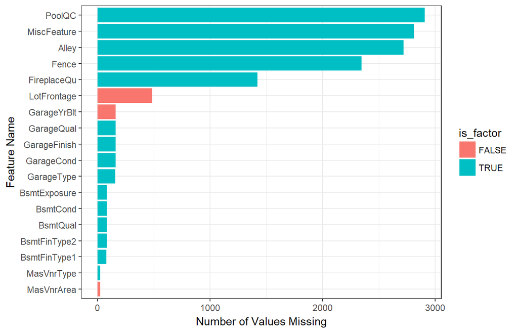

```r
missing_values <- df %>% summarize_all(funs(sum(is.na(.))))

missing_values <- gather(missing_values, key="feature", value="num_missing") %>%
    cbind(is_factor = facts)

missing_values %>%
    filter(num_missing>4) %>%
    ggplot(aes(x=reorder(feature,num_missing),y=num_missing, fill=is_factor)) +
    xlab("Feature Name") +
    ylab("Number of Values Missing") +
    geom_bar(stat="identity")+
    coord_flip()+theme_bw()
```

There are so many missing values that they have to be dealt with.

# 2 Data Wrangling

## 2.1 Fix NA values

We create a useful function for automatically adding a level named “None” to in place of NA.

```r
add_na_lvl <- function(x,na_lvl = which(x %>% is.na)){
    levels(x) <- c(levels(x),"None")
    x[na_lvl] <- "None"
    return(x)
}
```

### 2.1.1 The Pools

Add new PoolQC feature for places with no pool area.

```r
noPools<- which(df$PoolArea==0 & is.na(df$PoolQC))

df$PoolQC <- add_na_lvl(df$PoolQC,noPools)
```

### 2.1.2 Misc Feature, Alley, Fence, Fire Place

We apply the function to the next biggest interlopers.

```r
cleanme <- c("MiscFeature", "Alley", "Fence", "FireplaceQu")
df[,cleanme] <- apply(df[,cleanme],2,add_na_lvl) %>% as.data.frame()
```

### 2.1.3 Lot Frontage

Sometimes there’s no numeric value. Maybe that’s the same as 0?

```r
which(df$LotFrontage==0)
```

```
## integer(0)
```

It seems like these might be houses at the end of a street.

```r
df$LotFrontage[is.na(df$LotFrontage)]=0
```

### 2.1.4 Garages

Make factor for places with no garage

```r
noGarage <- which(df$GarageArea==0)

cleanme <- c("GarageType", "GarageCond", "GarageFinish", "GarageQual")
df[,cleanme] <- apply(df[,cleanme],2, function(x) {
    add_na_lvl(x,noGarage)
}) %>% as.data.frame

df$GarageYrBlt[noGarage] <- 0
```

### 2.1.5 Basements

Get rid of NA values in places without a basement.

```r
cleanme = c("BsmtQual","BsmtCond","BsmtExposure","BsmtFinType1","BsmtFinType2")
noBsmnt <- which(df$BsmtFinSF1==0 & df$BsmtFinSF2==0 & df$BsmtUnfSF==0)

df[noBsmnt,cleanme] %>% as.tbl()
```

```
## # A tibble: 78 x 5
##    BsmtQual BsmtCond BsmtExposure BsmtFinType1 BsmtFinType2
##  *   <fctr>   <fctr>       <fctr>       <fctr>       <fctr>
##  1       NA       NA           NA           NA           NA
##  2       NA       NA           NA           NA           NA
##  3       NA       NA           NA           NA           NA
##  4       NA       NA           NA           NA           NA
##  5       NA       NA           NA           NA           NA
##  6       NA       NA           NA           NA           NA
##  7       NA       NA           NA           NA           NA
##  8       NA       NA           NA           NA           NA
##  9       NA       NA           NA           NA           NA
## 10       NA       NA           NA           NA           NA
## # ... with 68 more rows
```

```r
df[,cleanme] <- apply(df[,cleanme],2, function(x) {
    add_na_lvl(x,noBsmnt)
}) %>% as.data.frame
```

### 2.1.6 Masonry

```r
df$MasVnrType <- df$MasVnrType %>% add_na_lvl
df$MasVnrArea[df$MasVnrArea %>% is.na()] <- 0
```

## 2.2 Check NA vals

And then re-evaluate

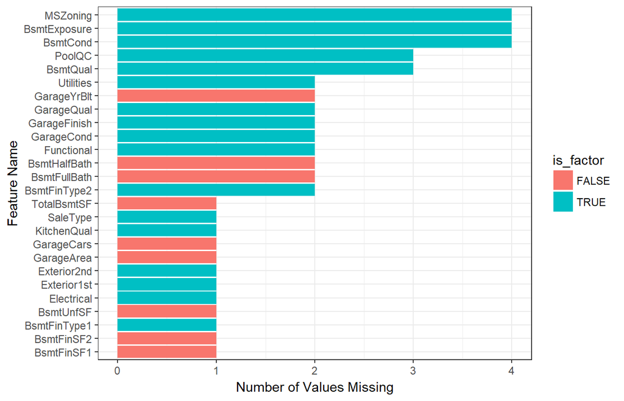

```r
missing_values <- df %>% summarize_all(funs(sum(is.na(.))))

missing_values <- gather(missing_values, key="feature", value="num_missing") %>%
    cbind(is_factor = facts)

missing_values %>%
    filter(num_missing>0) %>%
    ggplot(aes(x=reorder(feature,num_missing),y=num_missing, fill=is_factor)) +
    xlab("Feature Name") +
    ylab("Number of Values Missing") +
    geom_bar(stat="identity")+
    coord_flip()+theme_bw()
```

# 3 Modelling

Looking to minimize the Root Mean Squared Logarithmic Error

```r
target <- training %>% mutate(SalePrice=log(SalePrice))
training <- df %>% filter(Data=="Training") %>% mutate(SalePrice = target$SalePrice)
testing <- df %>% filter(Data=="Testing")
```

make it all numbers

```r
numbr_train <- training
# numbr_train <- apply(training,2,as.numeric) %>% as.data.frame()
for (i in 1:dim(numbr_train)[2]) {
    numbr_train[,i] <- numbr_train[,i] %>% as.numeric()
}

numbr_test <- testing
# numbr_test <- apply(testing,2,as.numeric) %>% as.data.frame()
for (i in 1:dim(numbr_test)[2]) {
    numbr_test[,i] <- numbr_test[,i] %>% as.numeric()
}
```

Next we partition

```r
set.seed(4321)
trainIndex <- createDataPartition(numbr_train$SalePrice, p = 0.8, list = FALSE, times = 1)

n_training <- numbr_train[trainIndex,]
n_validation <- numbr_train[-trainIndex,]
```

Reformat for XGB

```r
foo <- n_training %>% select(-c(SalePrice,Id,Data))
bar <- n_validation %>% select(-c(SalePrice,Id,Data))
baz <- numbr_test %>% select(-c(Id,Data))

dtrain <- xgb.DMatrix(as.matrix(foo),label = n_training$SalePrice)
dvalid <- xgb.DMatrix(as.matrix(bar),label = n_validation$SalePrice)
dtest <- xgb.DMatrix(as.matrix(baz))
```

Set the parameters

```r
xgb_params <- list(colsample_bytree = 0.5, #variables per tree
                   subsample = 1, #data subset per tree
                   booster = "gbtree",
                   max_depth = 6, #tree levels
                   eta = 0.3, #shrinkage
                   eval_metric = "rmse",
                   objective = "reg:linear",
                   seed = 4321
                   )

watchlist <- list(train=dtrain, valid=dvalid)
```

Run the thing

```r
set.seed(4321)
gb_dt <- xgb.train(params = xgb_params,
                   data = dtrain,
                   print_every_n = 25,
                   watchlist = watchlist,
                   nrounds = 300)
```

[output not shown]

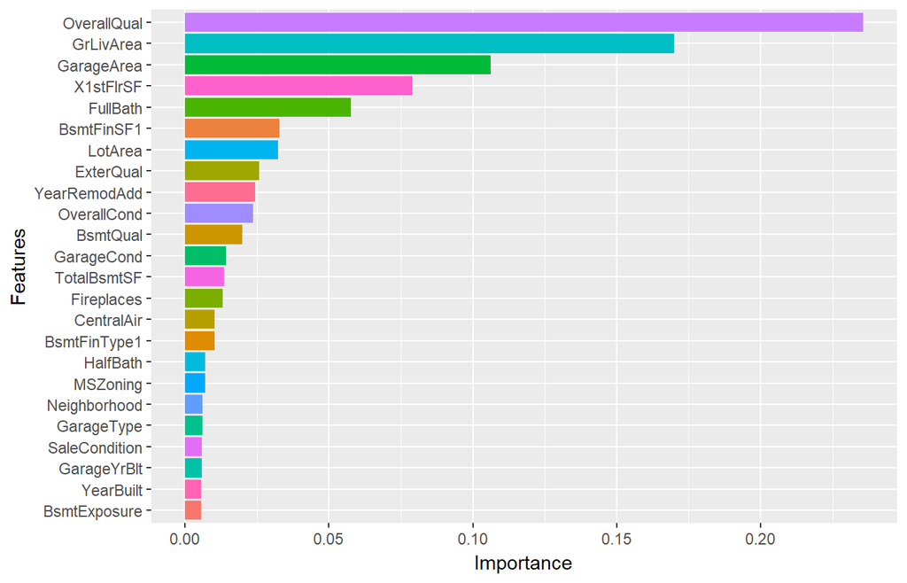

```r
imp_matrix <- xgb.importance(feature_names = colnames(foo), model = gb_dt)

imp_matrix %>% filter(Gain>.005) %>%
  ggplot(aes(reorder(Feature, Gain, FUN = max), Gain, fill = Feature)) +
  geom_col() +
  coord_flip() +
  theme(legend.position = "none") +
  labs(x = "Features", y = "Importance")
```

```r
pred1 <- predict(gb_dt,dtest)
pred1 <- exp(pred1)
```

Create output file

```r
pred <- testing %>% select(Id) %>% mutate(SalePrice=pred1)
pred %>% write_csv('submit.csv')
identical(dim(sample_sub),dim(pred))
```

```
## [1] TRUE
```